# Activity: Nuclear Reactors

Madeline Mucciolo

```r
library(tidyverse)
```

- Load *tidyverse* into the environment for later use.

## Scrape the Data

```r
library(rvest)

page <- "https://en.wikipedia.org/wiki/List_of_commercial_nuclear_reactors"
tableList <- page %>%
  read_html() %>%
  html_nodes(css = "table") %>%
  html_table(fill = TRUE)
```

- Scraping the data from the Wiki Page and storing it in **tableList**.

```r
Japan <- tableList[[21]]
head(Japan)
```

| Plantname | UnitNo. | Type | Model | Status | Capacity(MW) | Beginbuilding | Commercialoperation | Closed |  |  |  |  |  |  |  |  |  |
| --- | --- | --- | --- | --- | --- | --- | --- | --- | --- | --- | --- | --- | --- | --- | --- | --- | --- |
| Plantname | UnitNo. | Type | Model | Status | Capacity(MW) | Beginbuilding | Commercialoperation | Closed | Fugen | 1 | HWLWR | ATR | Shut down | 148 | 10 May 1972 | 20 Mar 1979 | 29 Mar 2003 |
| Fukushima Daiichi | 1 | BWR | BWR-3 | Inoperable | 439 | 25 Jul 1967 | 26 Mar 1971 | 19 May 2011 | NA | NA | NA | NA | NA | NA | NA | NA | NA |
| Fukushima Daiichi | 2 | BWR | BWR-4 | Inoperable | 760 | 9 Jun 1969 | 18 Jul 1974 | 19 May 2011 | NA | NA | NA | NA | NA | NA | NA | NA | NA |
| Fukushima Daiichi | 3 | BWR | BWR-4 | Inoperable | 760 | 28 Dec 1970 | 27 Mar 1976 | 19 May 2011 | NA | NA | NA | NA | NA | NA | NA | NA | NA |
| Fukushima Daiichi | 4 | BWR | BWR-4 | Inoperable | 760 | 12 Feb 1973 | 12 Oct 1978 | 19 May 2011 | NA | NA | NA | NA | NA | NA | NA | NA | NA |
| Fukushima Daiichi | 5 | BWR | BWR-4 | Shut down | 760 | 22 May 1972 | 18 Apr 1978 | 17 Dec 2013 | NA | NA | NA | NA | NA | NA | NA | NA | NA |

- After searching through **tableList**, I found Japan to be the 21st element in the list. I took that data, and stored it in a new variable named **Japan**.

## Your turn: In what ways is the table tidy? How is it not tidy? What’s different about it from a tidy table?

- The table is tidy because each column is a variable with the same type of value for each row. Most of the rows represent the nuclear reactors [each case is the Name of the plant and the UnitNo. of that specific reactor].
- However, the table is not tidy because the first row does is a repeat of the column names, which means it does not represent the same underlying case as all of the other rows. Some variable names are long and have spaces.

```r
print(Japan[10][[1]][1])
```

```
[1] "Fugen"
```

- When scraping my data, not only did the column names duplicate into their own case, but added the first case on the end of that row. Because of this, I have 9 extra columns that only contain one row of data. However, I cannot delete this row altogether since it contains data. Unfortunaly, these columns do not have names (they are empty strings), so they cannot be directly called upon. After playing around, I found the syntax needed to extract the data from these columns, as seen above.
- To use this data, I will need to individually extract it all, and add them into a new vector. This vector can then be added into the correct columns in the data frame.

```r
new_data <- c(Japan[10][[1]][1], Japan[11][[1]][1], Japan[13][[1]][1], Japan[14][[1]][1], Japan[15][[1]][1], Japan[16][[1]][1], Japan[17][[1]][1], Japan[18][[1]][1])
new_data
```

```
[1] "Fugen"       "1"           "ATR"         "Shut down"   "148"         "10 May 1972" "20 Mar 1979" "29 Mar 2003"
```

```r
library(dplyr)
colnames(Japan)
```

```
 [1] "Plantname"           "UnitNo."             "Type"                "Model"               "Status"              "Capacity(MW)"
 [7] "Beginbuilding"       "Commercialoperation" "Closed"              ""                    ""                    ""
[13] ""                    ""                    ""                    ""                    ""                    ""
```

- Looking at column names for renaming purposes, since they differ from the original names the book provided.

```r
names(Japan)[c(3)] <- c("type")

Japan <-
  Japan %>%
  select(Plantname, "UnitNo.", Model, Status, "Capacity(MW)", "Beginbuilding", "Commercialoperation", "Closed") %>%
  rename(name = Plantname,
         reactor = "UnitNo.",
         model = Model,
         status = Status,
         netMW = "Capacity(MW)",
         construction = "Beginbuilding",
         operation = "Commercialoperation")

head(Japan)
```

| name | reactor | model | status | netMW | construction | operation | Closed |
| --- | --- | --- | --- | --- | --- | --- | --- |
| Plantname | UnitNo. | Model | Status | Capacity(MW) | Beginbuilding | Commercialoperation | Closed |
| Fukushima Daiichi | 1 | BWR-3 | Inoperable | 439 | 25 Jul 1967 | 26 Mar 1971 | 19 May 2011 |
| Fukushima Daiichi | 2 | BWR-4 | Inoperable | 760 | 9 Jun 1969 | 18 Jul 1974 | 19 May 2011 |
| Fukushima Daiichi | 3 | BWR-4 | Inoperable | 760 | 28 Dec 1970 | 27 Mar 1976 | 19 May 2011 |
| Fukushima Daiichi | 4 | BWR-4 | Inoperable | 760 | 12 Feb 1973 | 12 Oct 1978 | 19 May 2011 |
| Fukushima Daiichi | 5 | BWR-4 | Shut down | 760 | 22 May 1972 | 18 Apr 1978 | 17 Dec 2013 |

- Now the variables have more uniform and usable names. Although the book completely removed the first row (to get rid of the doubled column names), since in my case I need to add **new_data** to the first row, I kept it for now.

```r
for(i in 1:8){Japan[i][[1]][1]<-new_data[i]}
```

```r
Japan
```

| name | reactor | model | status | netMW | construction | operation | Closed |
| --- | --- | --- | --- | --- | --- | --- | --- |
| Fugen | 1 | ATR | Shut down | 148 | 10 May 1972 | 20 Mar 1979 | 29 Mar 2003 |
| Fukushima Daiichi | 1 | BWR-3 | Inoperable | 439 | 25 Jul 1967 | 26 Mar 1971 | 19 May 2011 |
| Fukushima Daiichi | 2 | BWR-4 | Inoperable | 760 | 9 Jun 1969 | 18 Jul 1974 | 19 May 2011 |
| Fukushima Daiichi | 3 | BWR-4 | Inoperable | 760 | 28 Dec 1970 | 27 Mar 1976 | 19 May 2011 |
| Fukushima Daiichi | 4 | BWR-4 | Inoperable | 760 | 12 Feb 1973 | 12 Oct 1978 | 19 May 2011 |
| Fukushima Daiichi | 5 | BWR-4 | Shut down | 760 | 22 May 1972 | 18 Apr 1978 | 17 Dec 2013 |
| Fukushima Daiichi | 6 | BWR-5 | Shut down | 1067 | 26 Oct 1973 | 24 Oct 1979 | 17 Dec 2013 |
| Fukushima Daini | 1 | BWR-5 | Shut down | 1067 | 16 Mar 1976 | 20 Apr 1982 | 30 Sep 2019 |
| Fukushima Daini | 2 | BWR-5 | Shut down | 1067 | 25 May 1979 | 3 Feb 1984 | 30 Sep 2019 |
| Fukushima Daini | 3 | BWR-5 | Shut down | 1067 | 23 Mar 1981 | 21 Jun 1985 | 30 Sep 2019 |

[output cut: 59 more lines]

- After doing some data wrangling, the table is much easier to read, but still needs some adjustments. Many of the rows are not the appropriate type of variable. To fix this, I need to use *mutate()* on the columns that need fixed.

```r
str(Japan)
```

```
tibble [69 × 8] (S3: tbl_df/tbl/data.frame)
 $ name        : chr [1:69] "Fugen" "Fukushima Daiichi" "Fukushima Daiichi" "Fukushima Daiichi" ...
 $ reactor     : chr [1:69] "1" "1" "2" "3" ...
 $ model       : chr [1:69] "ATR" "BWR-3" "BWR-4" "BWR-4" ...
 $ status      : chr [1:69] "Shut down" "Inoperable" "Inoperable" "Inoperable" ...
 $ netMW       : chr [1:69] "148" "439" "760" "760" ...
 $ construction: chr [1:69] "10 May 1972" "25 Jul 1967" "9 Jun 1969" "28 Dec 1970" ...
 $ operation   : chr [1:69] "20 Mar 1979" "26 Mar 1971" "18 Jul 1974" "27 Mar 1976" ...
 $ Closed      : chr [1:69] "29 Mar 2003" "19 May 2011" "19 May 2011" "19 May 2011" ...
```

- After inspection using str(), it is known that all of the variables are written in the data as character type.

```r
library(lubridate)
```

- Loading the *lubridate* package into the environment to use in the next step.

```r
Japan <-
  Japan %>%
  mutate(reactor=as.numeric(reactor), netMW=as.numeric(netMW)) %>%
  mutate(construction=dmy(construction), operation=dmy(operation), Closed=dmy(Closed))
str(Japan)
```

```
tibble [69 × 8] (S3: tbl_df/tbl/data.frame)
 $ name        : chr [1:69] "Fugen" "Fukushima Daiichi" "Fukushima Daiichi" "Fukushima Daiichi" ...
 $ reactor     : num [1:69] 1 1 2 3 4 5 6 1 2 3 ...
 $ model       : chr [1:69] "ATR" "BWR-3" "BWR-4" "BWR-4" ...
 $ status      : chr [1:69] "Shut down" "Inoperable" "Inoperable" "Inoperable" ...
 $ netMW       : num [1:69] 148 439 760 760 760 ...
 $ construction: Date[1:69], format: "1972-05-10" "1967-07-25" "1969-06-09" "1970-12-28" ...
 $ operation   : Date[1:69], format: "1979-03-20" "1971-03-26" "1974-07-18" "1976-03-27" ...
 $ Closed      : Date[1:69], format: "2003-03-29" "2011-05-19" "2011-05-19" "2011-05-19" ...
```

## Your Turn: Plot Net Generation Capacity vs Construction Date

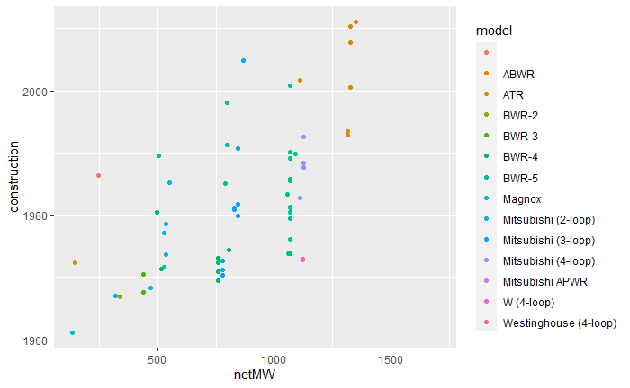

```r
ggplot(data=Japan, aes(x=netMW, y=construction, color=model)) +
  geom_point()
```

- From that graph above, on average, the newer the reactor was built, to more netMW it produces. The graph also sheds light on the popularity of different reactors during different times. *ABWR* models are the most recently used and also produce the most output.

## Your Turn: Scrape & Clean China Data (then merge with Japan)

```r
China <- tableList[[10]]
head(China)
```

| Plantname | UnitNo. | Type | Model | Status | Capacity(MW) | Beginbuilding | Commercialoperation | Closed |  |  |  |  |  |  |  |  |  |
| --- | --- | --- | --- | --- | --- | --- | --- | --- | --- | --- | --- | --- | --- | --- | --- | --- | --- |
| Plantname | UnitNo. | Type | Model | Status | Capacity(MW) | Beginbuilding | Commercialoperation | Closed | Bailong | 1 | PWR | CAP-1000 | Planned | 1100 | NA | NA | NA |
| 2 | PWR | CAP-1000 | Planned | 1100 |  |  |  | NA | Bailong | NA | NA | NA | NA | NA | NA | NA | NA |
| Changjiang | I-1 | PWR | CNP-600 | Operational | 601 | 25 Apr 2010 | 25 Dec 2015 |  | NA | NA | NA | NA | NA | NA | NA | NA | NA |
| Changjiang | I-2 | PWR | CNP-600 | Operational | 601 | 21 Nov 2010 | 20 Jun 2016 |  | NA | NA | NA | NA | NA | NA | NA | NA | NA |
| Changjiang | I-3[21] | PWR | Hualong One | Under construction | 1200 | 31 Mar 2021[22] |  |  | NA | NA | NA | NA | NA | NA | NA | NA | NA |
| Changjiang | I-4[21] | PWR | Hualong One | Under construction | 1200 | 31 Mar 2021[22] |  |  | NA | NA | NA | NA | NA | NA | NA | NA | NA |

- First finding China from the tabelList and looking at the data to see what needs to be cleaned.

```r
new_data_1 <- c(China[10][[1]][1], China[11][[1]][1], China[12][[1]][1], China[13][[1]][1], China[14][[1]][1], China[15][[1]][1], China[16][[1]][1], China[17][[1]][1], China[18][[1]][1])
new_data_2 <- c(China[10][[1]][1], China[1][[1]][2], China[2][[1]][2], China[3][[1]][2], China[4][[1]][2], China[5][[1]][2], China[6][[1]][2], China[7][[1]][2], China[8][[1]][2])

new_data_1
```

```
[1] "Bailong"  "1"        "PWR"      "CAP-1000" "Planned"  "1100"     NA         NA         NA
```

```r
new_data_2
```

```
[1] "Bailong"  "2"        "PWR"      "CAP-1000" "Planned"  "1100"     ""         ""         ""
```

- Capture the data from the first two lines that is out of place to insert in the correct spots.

```r
for(i in 1:9){China[i][[1]][1]<-new_data_1[i]}
for(i in 1:9){China[i][[1]][2]<-new_data_2[i]}
```

```r
China
```

| Plantname | UnitNo. | Type | Model | Status | Capacity(MW) | Beginbuilding | Commercialoperation | Closed |  |  |  |  |  |  |  |  |  |
| --- | --- | --- | --- | --- | --- | --- | --- | --- | --- | --- | --- | --- | --- | --- | --- | --- | --- |
| Bailong | 1 | PWR | CAP-1000 | Planned | 1100 | NA | NA | NA | Bailong | 1 | PWR | CAP-1000 | Planned | 1100 | NA | NA | NA |
| Bailong | 2 | PWR | CAP-1000 | Planned | 1100 |  |  |  | Bailong | NA | NA | NA | NA | NA | NA | NA | NA |
| Changjiang | I-1 | PWR | CNP-600 | Operational | 601 | 25 Apr 2010 | 25 Dec 2015 |  | NA | NA | NA | NA | NA | NA | NA | NA | NA |
| Changjiang | I-2 | PWR | CNP-600 | Operational | 601 | 21 Nov 2010 | 20 Jun 2016 |  | NA | NA | NA | NA | NA | NA | NA | NA | NA |
| Changjiang | I-3[21] | PWR | Hualong One | Under construction | 1200 | 31 Mar 2021[22] |  |  | NA | NA | NA | NA | NA | NA | NA | NA | NA |
| Changjiang | I-4[21] | PWR | Hualong One | Under construction | 1200 | 31 Mar 2021[22] |  |  | NA | NA | NA | NA | NA | NA | NA | NA | NA |
| Changjiang | II-1 | PWR | ACP-100 | Under construction | 100 | 13 Jul 2021 |  |  | NA | NA | NA | NA | NA | NA | NA | NA | NA |
| Changjiang | II-2 | PWR | ACP-100 | Planned | 100 |  |  |  | NA | NA | NA | NA | NA | NA | NA | NA | NA |
| Daya Bay | 1 | PWR | M-310 | Operational | 944 | 7 Aug 1987 | 1 Feb 1994 |  | NA | NA | NA | NA | NA | NA | NA | NA | NA |
| Daya Bay | 2 | PWR | M-310 | Operational | 944 | 7 Apr 1988 | 6 May 1994 |  | NA | NA | NA | NA | NA | NA | NA | NA | NA |

[output cut: 102 more lines]

- Now the first two lines have been replaced by the appropriate data. The extra columns on the end still need to be taken off, and the data still needs to be wrangled.

```r
China <-
  China %>%
  select(Plantname, "UnitNo.", Model, Status, "Capacity(MW)", "Beginbuilding", "Commercialoperation", "Closed") %>%
  rename(name = Plantname,
         reactor = "UnitNo.",
         model = Model,
         status = Status,
         netMW = "Capacity(MW)",
         construction = "Beginbuilding",
         operation = "Commercialoperation")

head(China)
```

| name | reactor | model | status | netMW | construction | operation | Closed |
| --- | --- | --- | --- | --- | --- | --- | --- |
| Bailong | 1 | CAP-1000 | Planned | 1100 | NA | NA | NA |
| Bailong | 2 | CAP-1000 | Planned | 1100 |  |  |  |
| Changjiang | I-1 | CNP-600 | Operational | 601 | 25 Apr 2010 | 25 Dec 2015 |  |
| Changjiang | I-2 | CNP-600 | Operational | 601 | 21 Nov 2010 | 20 Jun 2016 |  |
| Changjiang | I-3[21] | Hualong One | Under construction | 1200 | 31 Mar 2021[22] |  |  |
| Changjiang | I-4[21] | Hualong One | Under construction | 1200 | 31 Mar 2021[22] |  |  |

- The extra columns have been cut out and uniform names have been given to each.

```r
China <-
  China %>%
  mutate(reactor=as.numeric(reactor), netMW=as.numeric(netMW)) %>%
  mutate(construction=dmy(construction), operation=dmy(operation), Closed=dmy(Closed))
str(China)
```

```
tibble [112 × 8] (S3: tbl_df/tbl/data.frame)
 $ name        : chr [1:112] "Bailong" "Bailong" "Changjiang" "Changjiang" ...
 $ reactor     : num [1:112] 1 2 NA NA NA NA NA NA 1 2 ...
 $ model       : chr [1:112] "CAP-1000" "CAP-1000" "CNP-600" "CNP-600" ...
 $ status      : chr [1:112] "Planned" "Planned" "Operational" "Operational" ...
 $ netMW       : num [1:112] 1100 1100 601 601 1200 1200 100 100 944 944 ...
 $ construction: Date[1:112], format: NA NA "2010-04-25" "2010-11-21" ...
 $ operation   : Date[1:112], format: NA NA "2015-12-25" "2016-06-20" ...
 $ Closed      : Date[1:112], format: NA NA NA NA ...
```

- After converting all of the variables to their appropriate types, we can append *Japan* and *China*.

```r
# adding country variable to each table
China <-
  China %>%
  mutate("country" = "China")
Japan <-
  Japan %>%
  mutate('country' = "Japan")

# appending the tables
Japan_China <- bind_rows(Japan, China)
sample_n(Japan_China, 10)
```

| name | reactor | model | status | netMW | construction | operation | Closed | country |
| --- | --- | --- | --- | --- | --- | --- | --- | --- |
| Taohuajiang | 2 | CAP-1000 | Planned | 1100 |  |  |  | China |
| Fuqing | 1 | CPR-1000 | Operational | 1000 | 2008-11-21 | 2014-11-19 |  | China |
| Taishan | 1 | EPR | Operational | 1660 | 2009-11-18 |  |  | China |
| Fukushima Daiichi | 5 | BWR-4 | Shut down | 760 | 1972-05-22 | 1978-04-18 | 2013-12-17 | Japan |
| Taohuajiang | 1 | CAP-1000 | Planned | 1100 |  |  |  | China |
| Xiapu[46] | NA | CAP-1000 | Planned | 1100 |  |  |  | China |
| Genkai | 3 | Mitsubishi (4-loop) | Operational | 1127 | 1988-06-01 | 1994-03-18 |  | Japan |
| Higashidōri (Tōhoku) | 2 | ABWR | Planned | 1350 |  |  |  | Japan |
| Lianjiang[31] | 2 | CAP-1000 | Planned | 1100 |  |  |  | China |
| Changjiang | NA | ACP-100 | Under construction | 100 | 2021-07-13 |  |  | China |

## Your Turn: Reconstruct Info Graphic of Japan Reactors (or other country of interest)

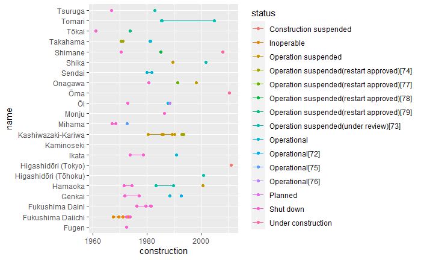

```r
Japan %>%
  ggplot(aes(x=construction, y=name, color=status)) + geom_line() + geom_point()
```

- In this graph, You can see the construction dates of different reactors at each location. The colors symbolize the status of the reactors (whether they are still operating or not).